# Scenario 1: Constant growth rate

## Mechanistic simulation

Populations will be simulated using a mechanistic approach according to a discrete Lotka-Volterra competition model.

In its simplest form, each population’s size will vary according to:

$$N_i(t+1) = N_i(t) + \lambda_i * N_i(t)$$
where $N_i$ is the size of population $i$, $t$ is each time step, and $\lambda$ is the true growth rate of population $i$.

The true growth rate is determined by:

$$\lambda_i = r*(1-\frac{(N_i(t) + \alpha_{ji}N_j(t))}{K_i})$$
where:
$r$ is population $i$’s maximum growth rate
$\alpha_{ji}$ is the interaction effect of population $j$ on population $i$
$N_j$ is the size of population $j$
$K_i$ is the carrying capacity of population $i$

#### Scenarios of population change

The largest threat to populations in the Living Planet Index is habitat degradation and loss. For this experiment, I will be changing the carrying capacity as a way to mimick habitat loss/degradation, in order to generate three possible populations trends:

- growing ($\frac{(N_i(t) + \alpha_{ji}N_j(t))}{K_i} < 1$)
- stable ($\frac{(N_i(t) + \alpha_{ji}N_j(t))}{K_i} = 1$)
- declining ($\frac{(N_i(t) + \alpha_{ji}N_j(t))}{K_i} > 1$)

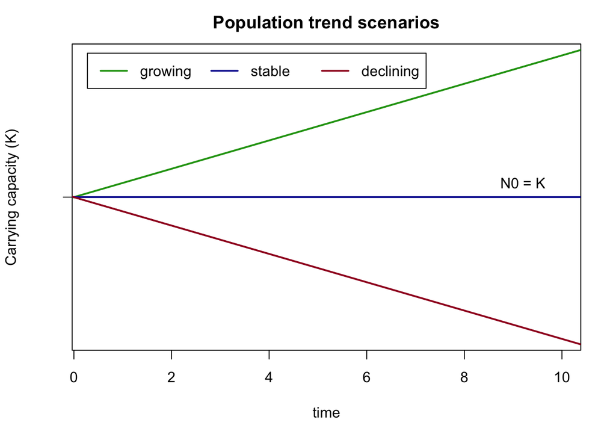

#### Source of covariation

Populations will be generated as antagonistic interaction partners, meaning the growth of one population will negatively impact the growth of its paired population (and vice-versa). I’m making this choice because this type of covariation reflects competition (directly, as the Lotka-Volterra equation is for this), which is likely to be prevalent in the Living Planet Database.

#### Sources of error

Population time series are subject to both observation error (i.e. “noisy” measurements of population size), and process error (i.e. environmental noise, demographic stochasticity, and other “noise” introduced into the processes that govern population size).

## Scenario 1

The parameters used to simulate population fluctuations using the equations above will be:

Simulation parameters

|  | i | j |
| --- | --- | --- |
| Initial size ($N0$) | 200 | 200 |
| Maximum growth rate ($r$) | 1 | 1 |
| Interaction effect ($\alpha$) | 0.1 | 0.1 |
| Observation error | +/-0.1 | +/-0.1 |
| Process error | +/-20 | +/-20 |

## Simulation

### The simulated populations

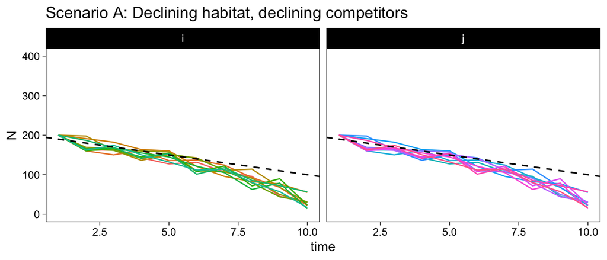

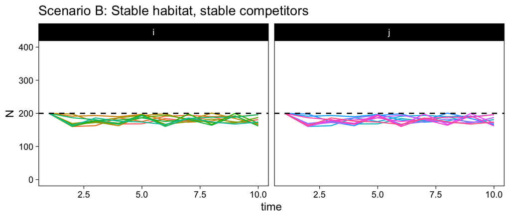

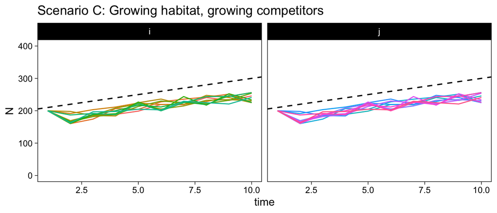

### Covariance & correlation structures

#### Scenario A: Declining habitat, declining competitors

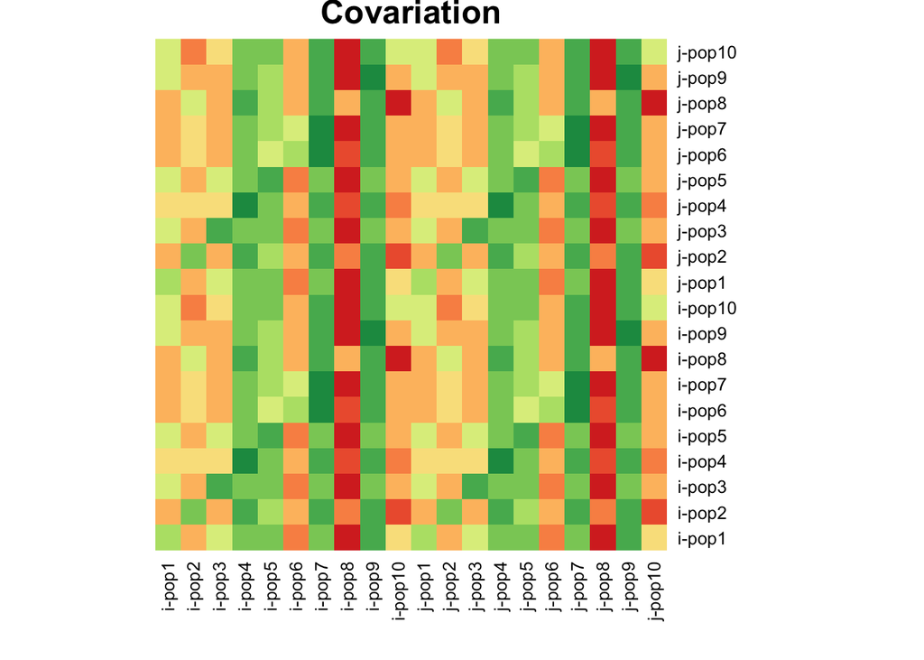

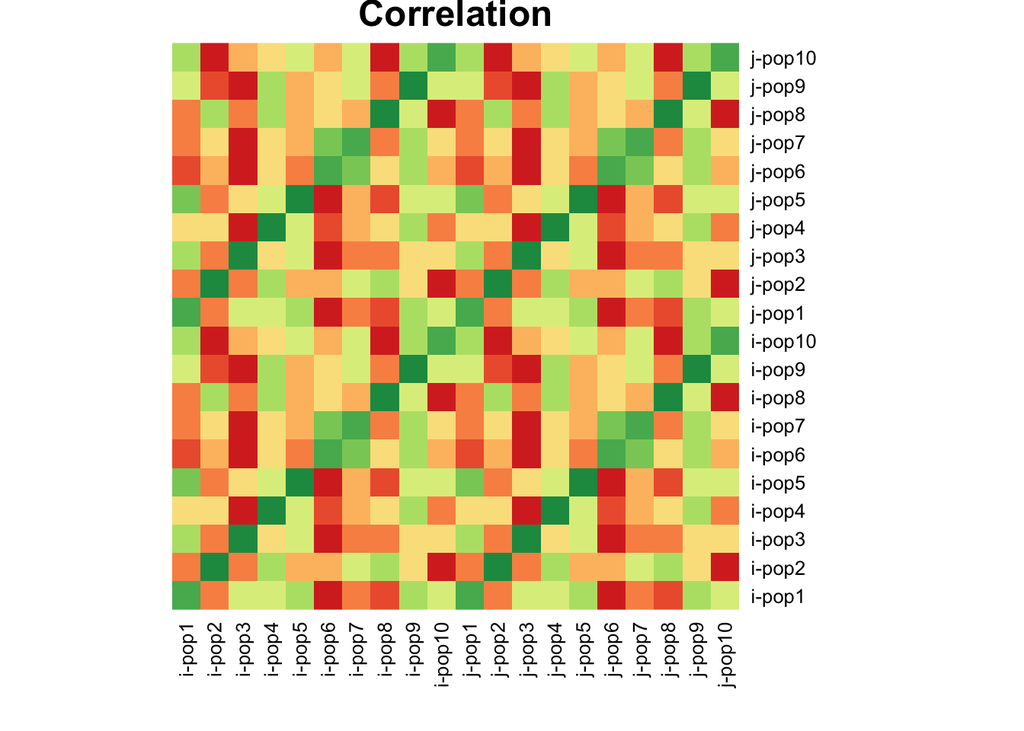

#### Scenario B: Stable habitat, stable competitors

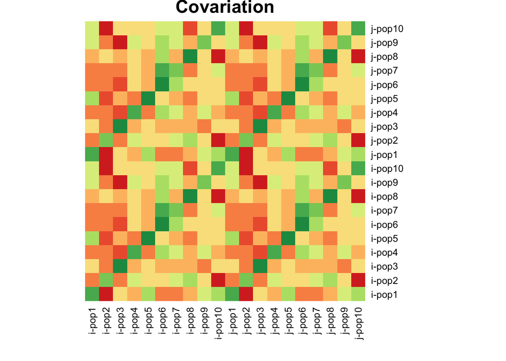

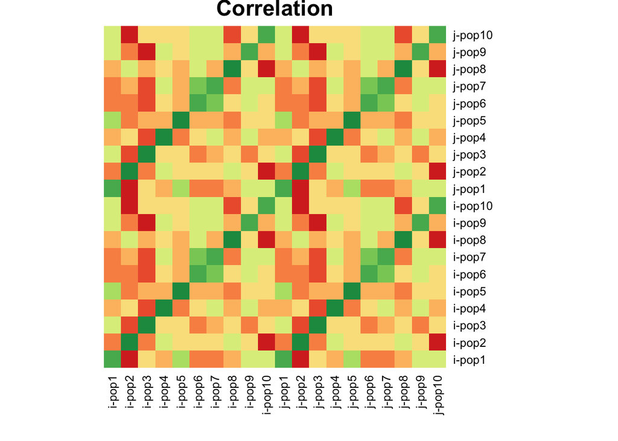

#### Scenario C: Growing habitat, growing competitors

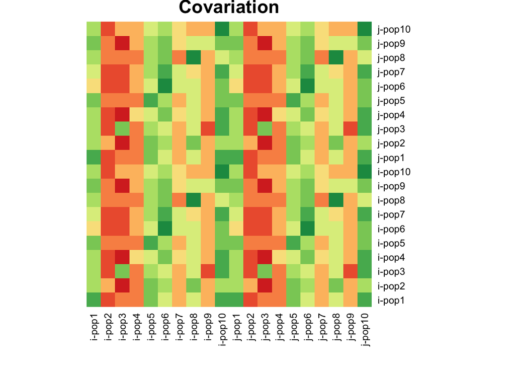

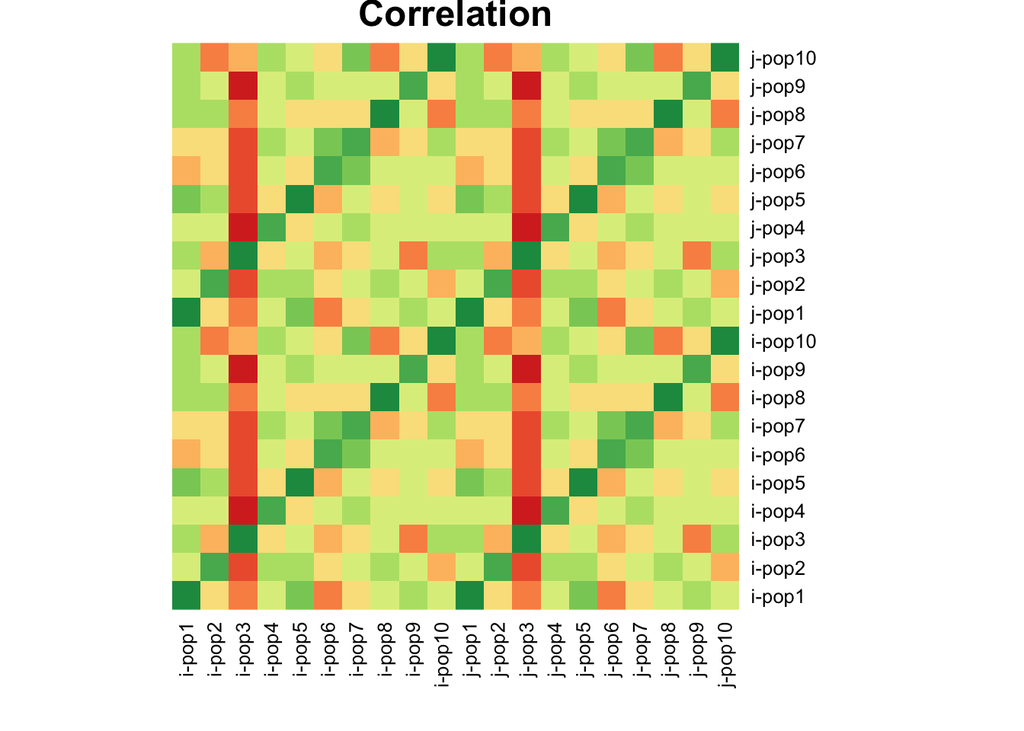

## Living Planet Index

#### Expected LPI

The true value of the LPI was calculated by generating populations with the same parameters outlined about, but without process and observation error. Instead of passing these populations through a GAM to generate predicted values on which the growth rate is calculated as in the LPI, growth rates are directly calculated from the population size changes between time steps.

The “observed” LPI will be compared against this true value later in the document to measure the accuracy and precision of the LPI in detecting these trends.

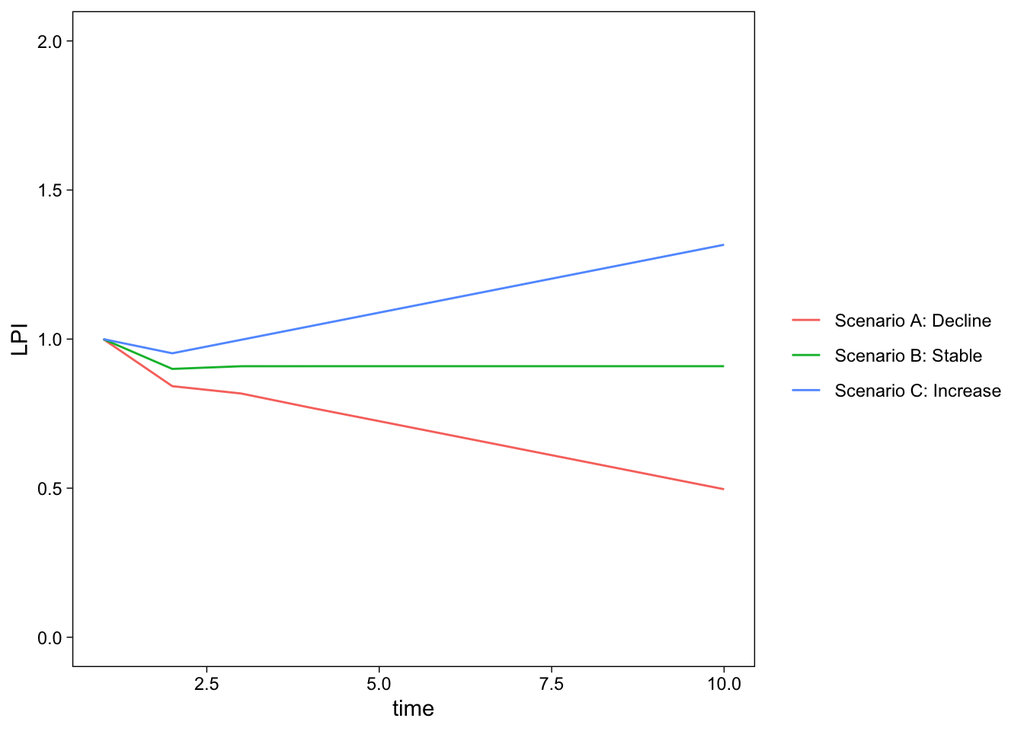

#### Observed LPI

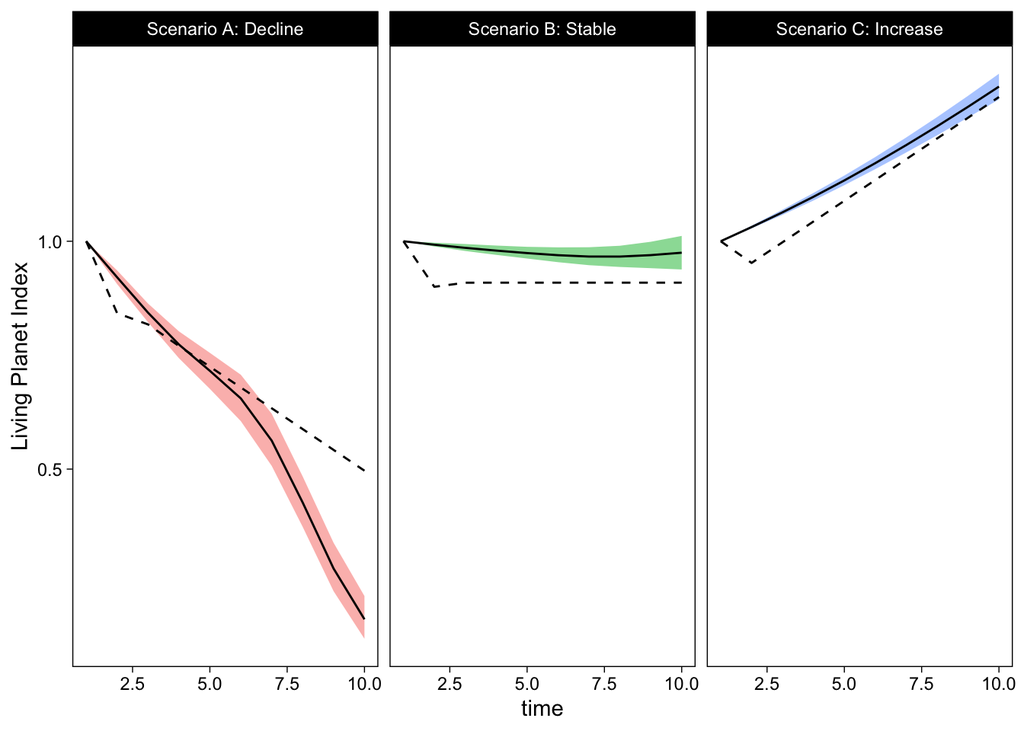

#### LPI Sensitivity

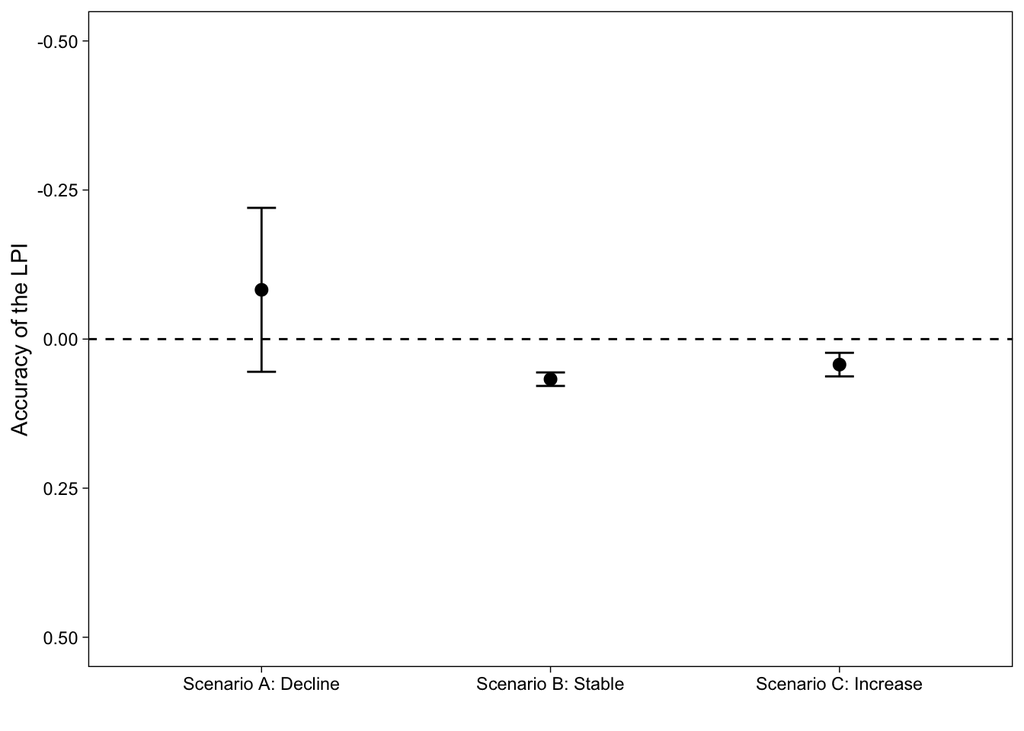